# Homework 08

Joe Dickerson

2025-03-25

```r
library(faraway)
library(tidyverse)
library(MASS)
data(rats)
```

2. An experiment was conducted as part of an investigation to combat the effects of certain toxic agents. The survival time of rats depended on the type of poison used and the treatment applied. The data is found in rats.
1. Make plots of the data and comment on differences between the treatments and poisons.

It appears that treatments B and D are more effective than A and C and treating the different poisons. None of the treatments are particularly effective with poison type III, however.

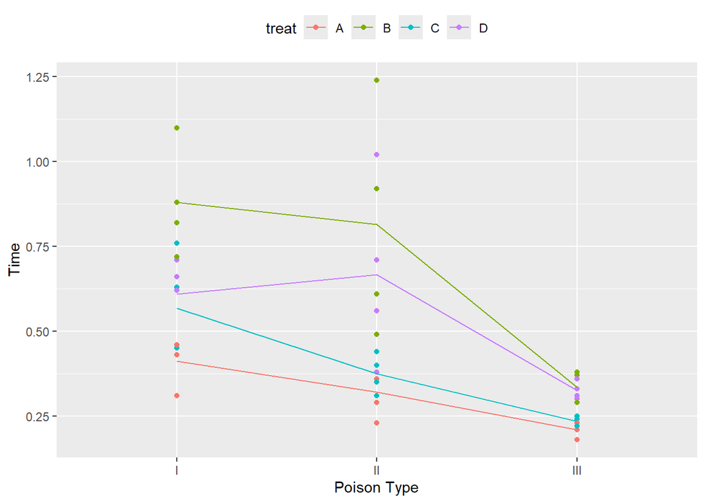

```r
rats %>%
  ggplot(aes(x = poison, y = time, color = treat)) +
  geom_point() +
  stat_summary(fun.y = "mean", geom = "line", aes(group = treat, color = treat)) +
  theme(legend.position = "top", legend.direction = "horizontal") +
  labs(x = "Poison Type", y = "Time")
```

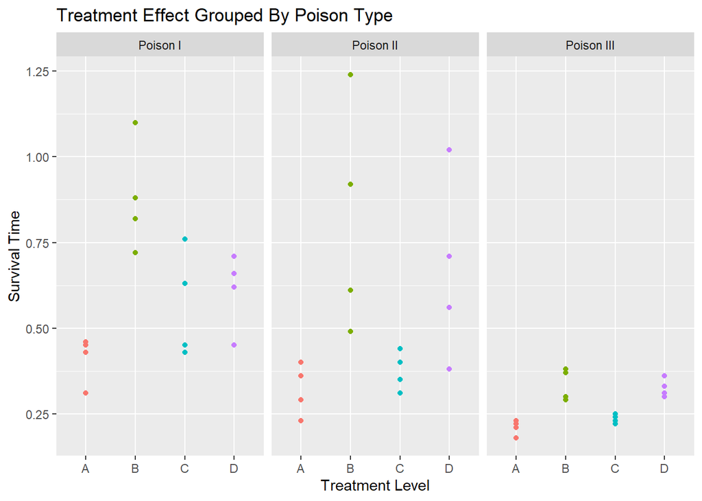

```r
rats %>% ggplot(aes(x = treat, y = time, color = treat)) +
  geom_point() +
  facet_grid(~ poison, labeller = as_labeller(c("I" = "Poison I",
                                                "II" = "Poison II",
                                                "III" = "Poison III"))) +
  labs(y = "Survival Time", x = "Treatment Level", title = "Treatment Effect Grouped By Poison Type") +
  theme(legend.position = "none")
```

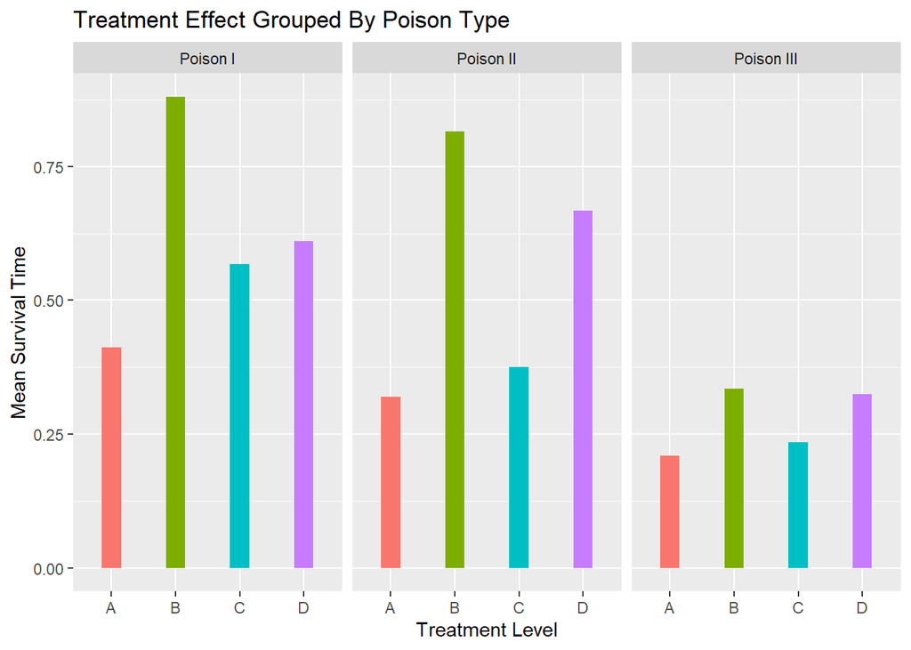

```r
rats2 <- rats %>%
  group_by(treat, poison) %>%
  summarize(time.mean = mean(time))

rats2 %>% ggplot(aes(x = treat, y = time.mean, fill = treat)) +
  geom_col(width = .3) +
  facet_grid(~ poison, labeller = as_labeller(c("I" = "Poison I",
                                                "II" = "Poison II",
                                                "III" = "Poison III"))) +
  labs(y = "Mean Survival Time", x = "Treatment Level", title = "Treatment Effect Grouped By Poison Type") +
  theme(legend.position = "none")
```

2. Fit a linear model with an interaction between the two predictors. Use the Box-Cox method to determine an optimal transformation on the response. Can this optimal transformation be rounded to a more interpretable function?

Using the Box-Cox method, we find a lambda value of -0.8282828. An inverse transformation might be more interpretable, i.e. using -1 for lambda.

```r
lmod <- lm(time ~ treat*poison, rats)

bc <- boxcox(lmod)
```

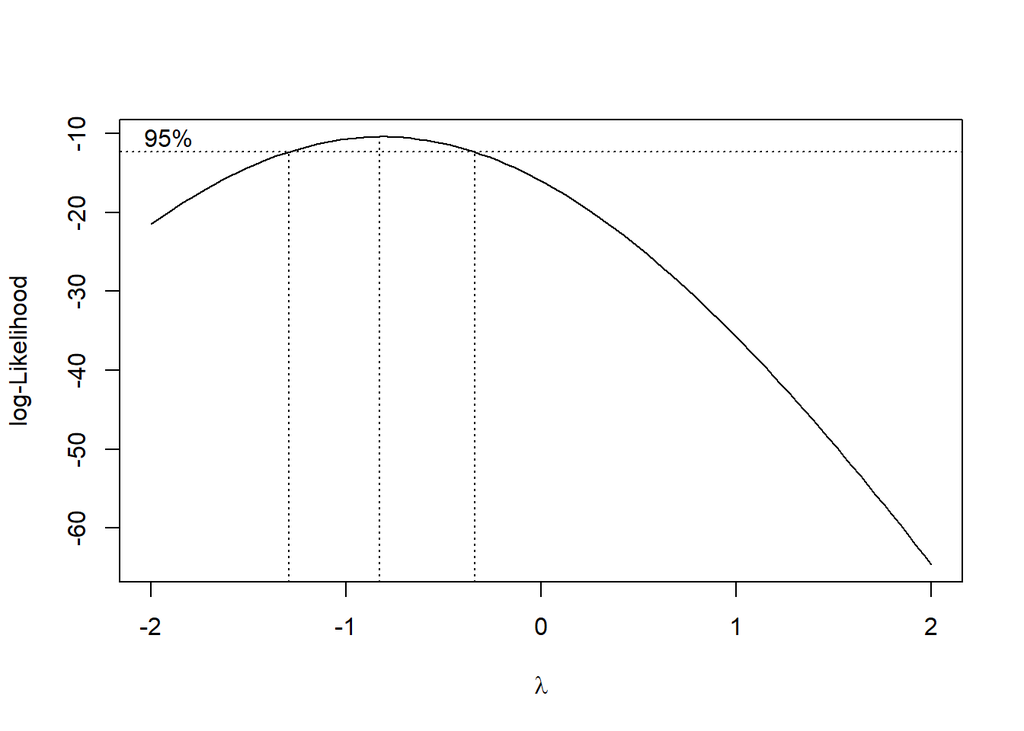

```r
lambda <- bc$x[which.max(bc$y)]

lambda
```

```
## [1] -0.8282828
```

3. Refit the model using your chosen interpretable transformation. Check the standard diagnostics and report any problems.

Our diagnostic plots are acceptable, however the summary output of the model indicates that the interaction terms might not be significant.

```r
time_new <- (rats$time^-1 - 1) / -1

lmod2 <- lm(time_new ~ treat*poison, rats)

summary(lmod2)
```

```
##
## Call:
## lm(formula = time_new ~ treat * poison, data = rats)
##
## Residuals:
##      Min       1Q   Median       3Q      Max
## -1.07936 -0.25458  0.06914  0.29642  0.76847
##
## Coefficients:
##                  Estimate Std. Error t value Pr(>|t|)
## (Intercept)      -1.48688    0.24499  -6.069 5.62e-07 ***
## treatB            1.32342    0.34647   3.820 0.000508 ***
## treatC            0.62416    0.34647   1.801 0.080010 .
## treatD            0.79720    0.34647   2.301 0.027297 *
## poisonII         -0.78159    0.34647  -2.256 0.030252 *
## poisonIII        -2.31580    0.34647  -6.684 8.56e-08 ***
## treatB:poisonII   0.55166    0.48999   1.126 0.267669
## treatC:poisonII  -0.06961    0.48999  -0.142 0.887826
## treatD:poisonII   0.76974    0.48999   1.571 0.124946
## treatB:poisonIII  0.45030    0.48999   0.919 0.364213
## treatC:poisonIII -0.08646    0.48999  -0.176 0.860928
## treatD:poisonIII  0.91368    0.48999   1.865 0.070391 .
## ---
## Signif. codes:  0 '***' 0.001 '**' 0.01 '*' 0.05 '.' 0.1 ' ' 1
##
## Residual standard error: 0.49 on 36 degrees of freedom
## Multiple R-squared:  0.8681, Adjusted R-squared:  0.8277
## F-statistic: 21.53 on 11 and 36 DF,  p-value: 1.289e-12
```

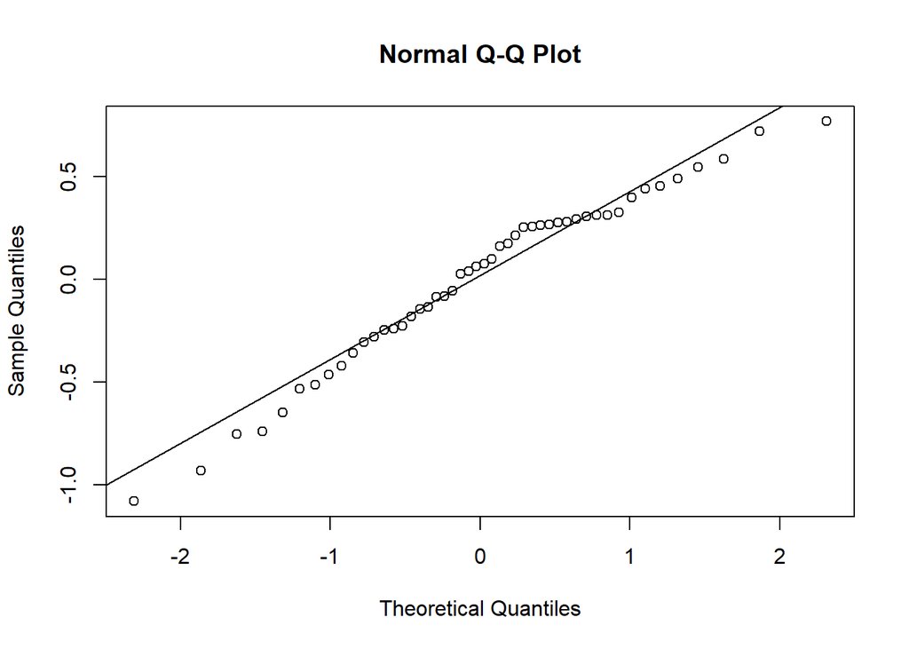

```r
qqnorm(residuals(lmod2))
qqline(residuals(lmod2))
```

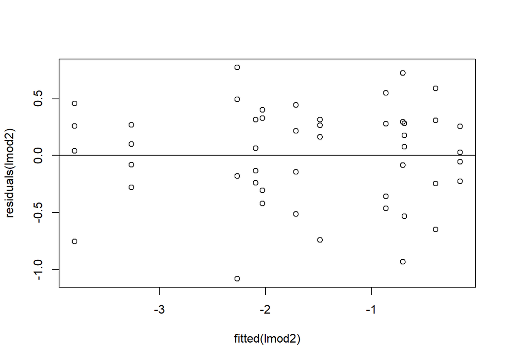

```r
plot(residuals(lmod2) ~ fitted(lmod2))
abline(h=0)
```

4. Is the interaction term significant? Simplify the model if justified and indicate which poison and treatment will result in the shortest survival time.

```r
anova(lmod2)
```

```
## Analysis of Variance Table
##
## Response: time_new
##              Df Sum Sq Mean Sq F value    Pr(>F)
## treat         3 20.414  6.8048 28.3431 1.376e-09 ***
## poison        2 34.877 17.4386 72.6347 2.310e-13 ***
## treat:poison  6  1.571  0.2618  1.0904    0.3867
## Residuals    36  8.643  0.2401
## ---
## Signif. codes:  0 '***' 0.001 '**' 0.01 '*' 0.05 '.' 0.1 ' ' 1
```

```r
lmod3 <- lm(time_new ~ treat + poison, rats)

summary(lmod3)
```

```
##
## Call:
## lm(formula = time_new ~ treat + poison, data = rats)
##
## Residuals:
##      Min       1Q   Median       3Q      Max
## -1.18153 -0.27568 -0.02116  0.37619  0.82757
##
## Coefficients:
##             Estimate Std. Error t value Pr(>|t|)
## (Intercept)  -1.6977     0.1744  -9.737 2.47e-12 ***
## treatB        1.6574     0.2013   8.233 2.66e-10 ***
## treatC        0.5721     0.2013   2.842  0.00689 **
## treatD        1.3583     0.2013   6.747 3.35e-08 ***
## poisonII     -0.4686     0.1744  -2.688  0.01026 *
## poisonIII    -1.9964     0.1744 -11.451 1.69e-14 ***
## ---
## Signif. codes:  0 '***' 0.001 '**' 0.01 '*' 0.05 '.' 0.1 ' ' 1
##
## Residual standard error: 0.4931 on 42 degrees of freedom
## Multiple R-squared:  0.8441, Adjusted R-squared:  0.8255
## F-statistic: 45.47 on 5 and 42 DF,  p-value: 6.974e-16
```

5. Build an inverse Gaussian GLM for this data. Select an appropriate link function consistent with the previous modeling. Perform diagnostics to verify your choice. Which poison and treatment will result in the shortest survival time?

```r
glm <- glm(time ~ treat + poison, family = inverse.gaussian(link="inverse"), rats)

summary(glm)
```

```
##
## Call:
## glm(formula = time ~ treat + poison, family = inverse.gaussian(link = "inverse"),
##     data = rats)
##
## Coefficients:
##             Estimate Std. Error t value Pr(>|t|)
## (Intercept)   2.6465     0.1939  13.648  < 2e-16 ***
## treatB       -1.6095     0.2110  -7.627 1.87e-09 ***
## treatC       -0.5835     0.2347  -2.486    0.017 *
## treatD       -1.2940     0.2187  -5.917 5.24e-07 ***
## poisonII      0.2900     0.1566   1.853    0.071 .
## poisonIII     1.9660     0.1929  10.192 6.34e-13 ***
## ---
## Signif. codes:  0 '***' 0.001 '**' 0.01 '*' 0.05 '.' 0.1 ' ' 1
##
## (Dispersion parameter for inverse.gaussian family taken to be 0.1139811)
##
##     Null deviance: 25.7437  on 47  degrees of freedom
## Residual deviance:  4.5888  on 42  degrees of freedom
## AIC: -85.701
##
## Number of Fisher Scoring iterations: 2
```

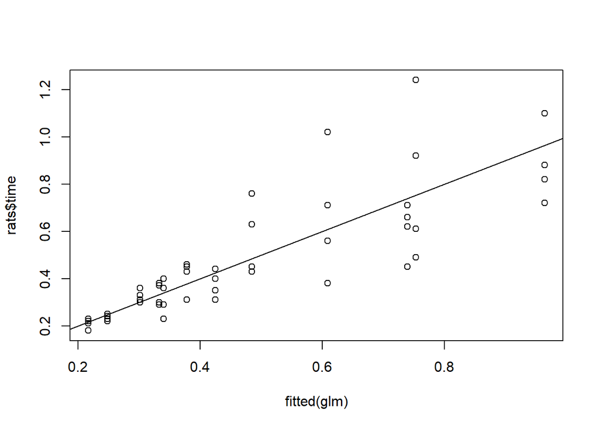

```r
plot(rats$time ~ fitted(glm))
abline(a=0, b=1)
```

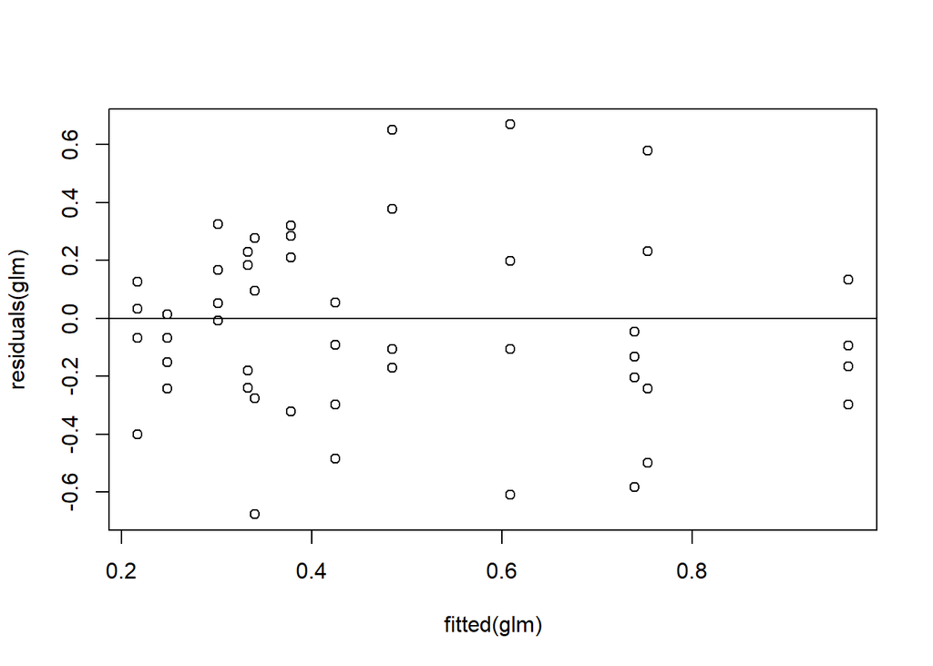

```r
plot(residuals(glm) ~ fitted(glm))
abline(h=0)
```

6. Compare the predicted values on the original scale of the response for the two models. Do the two models achieve a similar fit?

After transforming the predicted values to the original scale, the models do appear to have a similar fit. We compare the actual values to the fitted values for the two models and see very similar visuals.

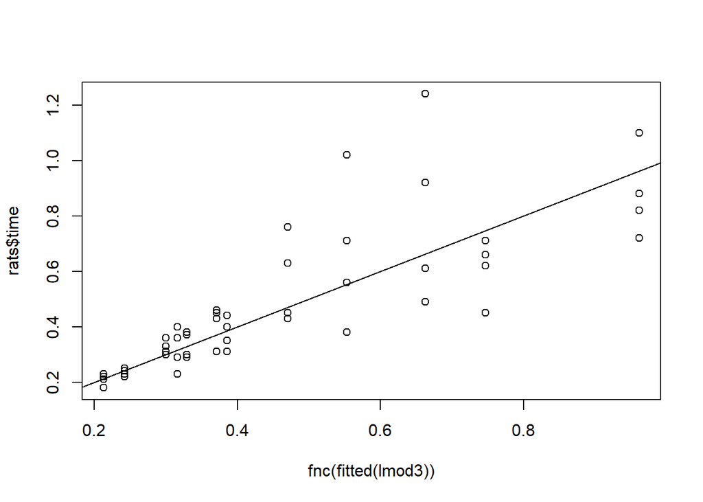

```r
time_new <- (rats$time^-1 - 1) / -1

fnc <- function(x){
  (-x + 1)^-1
}

plot(rats$time ~ fnc(fitted(lmod3)))
abline(a=0, b=1)
```

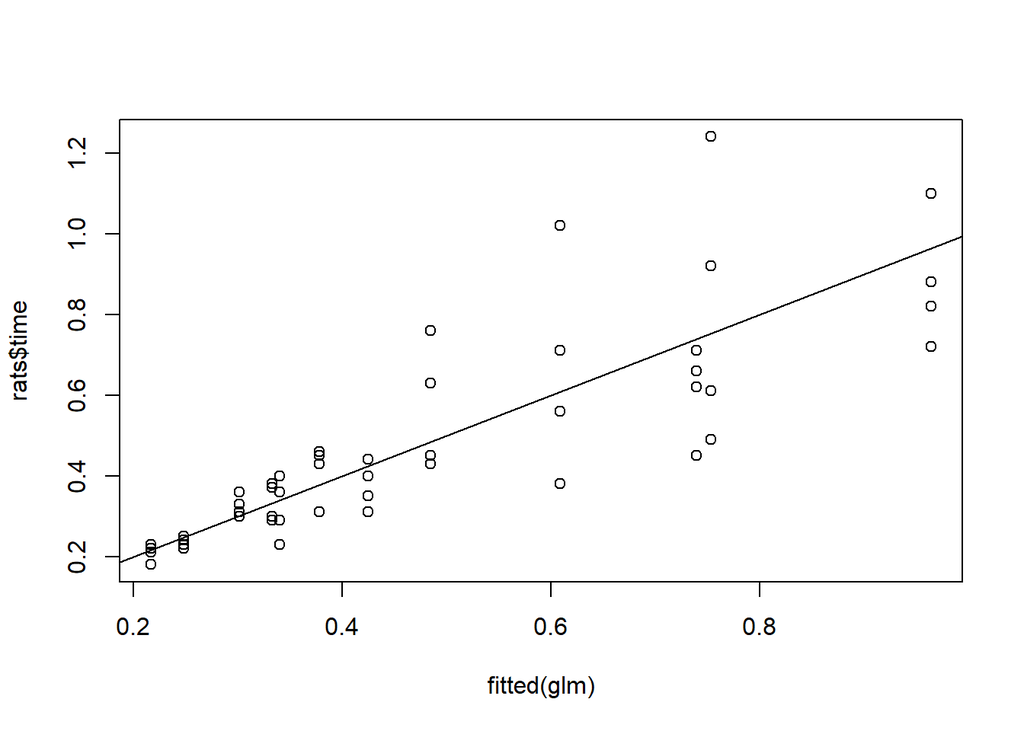

```r
plot(rats$time ~ fitted(glm))
abline(a=0, b=1)
```